# Lesson 2 - Statistics

Geoffrey Millard

July 17, 2019

## Picking up where we left off

For this lesson, we are going to use data from the United States Geological Survey. The same data we pulled from NWIS towards the end of lesson 1. (repeated here)

Switch to web Browser and go to NWIS Mapper: https://maps.waterdata.usgs.gov/mapper/index.html Find Honnedaga Lake gauges and sampling sites

```r
library(tidyverse)

#USGS and EPA dataset retrieval package
library(dataRetrieval)
#click on "Packages" tab to see functions available in the dataRetrival package

#these are the USGS sites upstream from Honnedaga Lake, NY that we found in the browser
sites <- c('0134277112', '0134277114')

#detailed location information about the site
readNWISsite(c('0134277112', '0134277114'))
```

```
##   agency_cd    site_no                                        station_nm
## 1      USGS 0134277112 HONNEDAGA LAKE TRIBUTARY NO. 2 NR FOREST LODGE NY
## 2      USGS 0134277114 HONNEDAGA LAKE TRIBUTARY NO. 3 NR FOREST LODGE NY
##   site_tp_cd   lat_va  long_va dec_lat_va dec_long_va coord_meth_cd
## 1         ST 433201.7 745142.6   43.53381   -74.86183             G
## 2         ST 433153.0 745110.5   43.53139   -74.85292             G
##   coord_acy_cd coord_datum_cd dec_coord_datum_cd district_cd state_cd
## 1            1          NAD83              NAD83          36       36
## 2            1          NAD83              NAD83          36       36
##   county_cd country_cd land_net_ds             map_nm map_scale_fc alt_va
## 1       043         US          NA HONNEDAGA LAKE, NY        24000   2200
## 2       043         US          NA HONNEDAGA LAKE, NY        24000   2200
##   alt_meth_cd alt_acy_va alt_datum_cd   huc_cd basin_cd topo_cd
## 1           D         10       NAVD88 02020004     <NA>       C
## 2           N         10       NAVD88 02020004     <NA>       C
##                   instruments_cd construction_dt inventory_dt
## 1 YNNNNNNNNNNNNNNNNNNNNNNNNNNNNN              NA           NA
## 2 YNNNNNNNNNNNNNNNNNNNNNNNNNNNNN              NA           NA
##   drain_area_va contrib_drain_area_va tz_cd local_time_fg reliability_cd
## 1          0.07                    NA   EST             N           <NA>
## 2          0.12                    NA   EST             N           <NA>
##   gw_file_cd nat_aqfr_cd aqfr_cd aqfr_type_cd well_depth_va hole_depth_va
## 1       <NA>        <NA>    <NA>         <NA>            NA            NA
## 2       <NA>        <NA>    <NA>         <NA>            NA            NA
##   depth_src_cd project_no
## 1         <NA>      HONNE
## 2         <NA>      HONNE
```

```r
#whatNWISdata displays the datasets available at each site
available <- whatNWISdata(siteNumber=c('0134277112', '0134277114'))
actual <- readNWISpCode(parameterCd = available$parm_cd) #interpret parameter codes
want <- c('00681', '00945', '50287', '50285') #we want: DOC, DSO4, DHg and DMeHg
data <- readNWISqw(siteNumbers = sites, parameterCd=want) #get the data
codes <- readNWISpCode(parameterCd = unique(data$parm_cd)) #confirms that we got what we wanted, shows UNITS!
View(data)
```

## What do we know?

Two sites and four parameters. How can we quickly generate some summary statistics? Piping!

```r
#first we need to name the parameter codes, so that we don't forget which code is which
data <- data %>% mutate(Analyte = recode(parm_cd,
                         '00681'= "DOC",
                         '00945' = "SO4",
                         '50287' = "Hg",
                         '50285' = "MeHg"))

data <- data %>% mutate(Site = recode(site_no,
                         '0134277112' = "Reference",
                         '0134277114' = "Treated"))


#summary stats
data %>% group_by(Site, Analyte) %>% summarize(average=mean(result_va, na.rm = T))
```

```
## # A tibble: 8 x 3
## # Groups:   Site [2]
##   Site      Analyte average
##   <chr>     <chr>     <dbl>
## 1 Reference DOC      4.70
## 2 Reference Hg       1.10
## 3 Reference MeHg     0.0644
## 4 Reference SO4      2.49
## 5 Treated   DOC      7.71
## 6 Treated   Hg       2.53
## 7 Treated   MeHg     0.101
## 8 Treated   SO4      2.93
```

## Yea, so?

We can do this for more than one summary statistic at a time!

```r
data %>%
  group_by(Site, Analyte) %>%
  summarize(average=mean(result_va),
            stdv=sd(result_va, na.rm=T),
            max=max(result_va, na.rm=T),
            min=min(result_va, na.rm=T),
            n = n())
```

```
## # A tibble: 8 x 7
## # Groups:   Site [2]
##   Site      Analyte average   stdv   max   min     n
##   <chr>     <chr>     <dbl>  <dbl> <dbl> <dbl> <int>
## 1 Reference DOC        4.70 1.22    9.14  2.75   134
## 2 Reference Hg         1.10 0.517   2.13  0.33    18
## 3 Reference MeHg      NA    0.0636  0.17  0.01    18
## 4 Reference SO4        2.49 0.501   3.79  1.22   168
## 5 Treated   DOC        7.71 3.29   18.6   2.87   138
## 6 Treated   Hg         2.53 1.34    5.5   0.69    21
## 7 Treated   MeHg      NA    0.0863  0.26  0.01    20
## 8 Treated   SO4        2.93 0.650   6.44  1.34   189
```

Awesome, but what if I wanted to look at this through time? Monthly or annual?

```r
library(lubridate)
class(data$sample_dt)
```

```
## [1] "Date"
```

```r
year(data$sample_dt)
```

```
##   [1] 2011 2011 2011 2011 2011 2011 2011 2011 2011 2011 2011 2011 2011 2011
##  [15] 2011 2011 2011 2011 2012 2012 2012 2012 2012 2012 2012 2012 2012 2012
##  [29] 2012 2012 2012 2012 2012 2012 2012 2012 2012 2012 2012 2012 2012 2012
##  [43] 2012 2012 2012 2012 2012 2012 2012 2012 2012 2012 2012 2012 2012 2012
##  [57] 2012 2012 2012 2012 2012 2012 2012 2012 2012 2012 2012 2012 2013 2013
##  [71] 2013 2013 2013 2013 2013 2013 2013 2013 2013 2013 2013 2013 2013 2013
##  [85] 2013 2013 2013 2013 2013 2013 2013 2013 2013 2013 2013 2013 2013 2013
##  [99] 2013 2013 2013 2013 2013 2013 2013 2013 2013 2013 2013 2013 2013 2013
## [113] 2013 2013 2013 2013 2013 2013 2013 2013 2013 2013 2013 2013 2013 2013
## [127] 2013 2013 2013 2013 2013 2013 2013 2013 2013 2013 2013 2013 2013 2013
## [141] 2013 2013 2013 2013 2013 2013 2013 2013 2013 2013 2014 2014 2014 2014
## [155] 2014 2014 2014 2014 2014 2014 2014 2014 2014 2014 2014 2014 2014 2014
## [169] 2014 2014 2014 2014 2014 2014 2014 2014 2014 2014 2014 2014 2014 2014
## [183] 2014 2014 2014 2014 2014 2014 2014 2014 2014 2014 2014 2014 2014 2014
## [197] 2014 2015 2015 2015 2015 2015 2015 2015 2015 2015 2015 2015 2015 2015
```

[output cut: 36 more lines]

```r
month(data$sample_dt)
```

```
##   [1]  5  5  6  6  7  7  8  8 10 10 10 10 11 11 11 11 12 12  1  1  3  3  3
##  [24]  3  3  3  3  3  4  4  5  5  6  6  6  6  6  6  7  7  7  7  7  7  7  7
##  [47]  8  8  8  8  8  8  8  8  8  8  9  9  9  9 10 10 10 10 10 10 11 11  1
##  [70]  1  3  3  4  4  4  4  4  4  4  4  5  5  6  6  6  6  6  6  6  6  6  6
##  [93]  6  6  7  7  7  7  7  7  7  7  7  7  8  8  8  8  9  9 10 10 10 10 10
## [116] 10 10 10 10 10 10 10 10 10 10 10 10 10 10 10 10 10 10 10 11 11 11 11
## [139] 11 11 11 11 11 11 11 11 11 11 11 11  1  1  1  1  2  2  2  2  3  3  3
## [162]  3  4  4  4  4  4  4  5  5  6  6  6  6  6  6  7  7  8  8  8  8  9  9
## [185]  9  9  9  9 10 10 11 12 12 12 12 12 12  3  3  3  3  3  3  4  4  4  4
## [208]  5  5  6  6  6  6  6  6  6  6  6  6  6  6  7  7  7  7  8  8  8  8  8
## [231]  8  9  9  9  9 10 10 10 10 10 10 11 11 11 11 11 11 12 12 12 12 12 12
## [254] 12 12  1  1  1  1  1  1  3  3  3  3  3  3  4  4  4  4  5  5  5  5  6
## [277]  6  6  6  6  6  6  7  7  7  7  7  7  8  8  8  8  8  8  8  8  9  9  9
## [300]  9 10 10 10 10 12 12 12 12  3  3  3  4  5  6  6  6  7  7  7  8  9 10
## [323] 10 10 10 11 11 11 11  1  2  2  2  3  4  5  6  7  5  5  6  6  7  7  8
```

[output cut: 16 more lines]

```r
summary <- data %>%
  group_by(Site, Analyte, year(sample_dt), month(sample_dt)) %>%
  summarize(average=mean(result_va),
            stdv=sd(result_va, na.rm=T),
            max=max(result_va, na.rm=T),
            min=min(result_va, na.rm=T),
            n = n())
summary
```

```
## # A tibble: 328 x 9
## # Groups:   Site, Analyte, year(sample_dt) [48]
##    Site  Analyte `year(sample_dt~ `month(sample_d~ average    stdv   max
##    <chr> <chr>              <dbl>            <dbl>   <dbl>   <dbl> <dbl>
##  1 Refe~ DOC                 2011                5    4.93 NA       4.93
##  2 Refe~ DOC                 2011                6    3.72 NA       3.72
##  3 Refe~ DOC                 2011                7    3.3  NA       3.3
##  4 Refe~ DOC                 2011                8    3.58 NA       3.58
##  5 Refe~ DOC                 2011               10    4.30  0.219   4.46
##  6 Refe~ DOC                 2011               11    4.55  0.0566  4.59
##  7 Refe~ DOC                 2011               12    4.14 NA       4.14
##  8 Refe~ DOC                 2012                1    3.33 NA       3.33
##  9 Refe~ DOC                 2012                3    3.47  0.212   3.68
## 10 Refe~ DOC                 2012                4    3.24 NA       3.24
## # ... with 318 more rows, and 2 more variables: min <dbl>, n <int>
```

Custom groupings are a little more complicated, but can be done. #pre and post treatment data (Creating categorical variables from continuous variables) pre-treatment (Group 1), post-treatment (Group 2), long-term post-treatment (Group 3)

```r
data$Treatment[ data$sample_dt < as.Date('2013-10-1')  ] <- 1
data$Treatment[ data$sample_dt >= as.Date('2013-10-1') ] <- 2
data$Treatment[ data$sample_dt > as.Date('2014-02-28') ] <- 3

data %>%
  group_by(Site, Analyte, Treatment) %>%
  summarize(average=mean(result_va, na.rm = T),
            stdv=sd(result_va, na.rm=T),
            max=max(result_va, na.rm=T),
            min=min(result_va, na.rm=T),
            n = n())
```

```
## # A tibble: 24 x 8
## # Groups:   Site, Analyte [8]
##    Site      Analyte Treatment average    stdv   max   min     n
##    <chr>     <chr>       <dbl>   <dbl>   <dbl> <dbl> <dbl> <int>
##  1 Reference DOC             1  4.46    1.02    7.67  2.85    54
##  2 Reference DOC             2  5.43    1.34    8.14  3.18    17
##  3 Reference DOC             3  4.71    1.29    9.14  2.75    63
##  4 Reference Hg              1  1.15   NA       1.15  1.15     1
##  5 Reference Hg              2  1.37    0.613   2.13  0.53     7
##  6 Reference Hg              3  0.911   0.400   1.61  0.33    10
##  7 Reference MeHg            1  0.04   NA       0.04  0.04     1
##  8 Reference MeHg            2  0.0186  0.0157  0.05  0.01     7
##  9 Reference MeHg            3  0.108   0.0643  0.17  0.01    10
## 10 Reference SO4             1  2.86    0.462   3.79  1.89    54
## # ... with 14 more rows
```

This makes it really easy to break your data down in a variety of ways relatively quickly.

## Linear models and correlations

We have some descriptive stats, but we want to see if there are any relationships in our data. Base-R has some pretty good tools for this, but they don’t work very well with data in long format, so we need to switch to a wide format.

```r
head(data)
```

```
##   agency_cd    site_no  sample_dt sample_tm sample_end_dt sample_end_tm
## 1      USGS 0134277112 2011-05-16     00:00            NA          <NA>
## 2      USGS 0134277112 2011-05-16     00:00            NA          <NA>
## 3      USGS 0134277112 2011-06-06     09:25            NA          <NA>
## 4      USGS 0134277112 2011-06-06     09:25            NA          <NA>
## 5      USGS 0134277112 2011-07-19     12:25            NA          <NA>
## 6      USGS 0134277112 2011-07-19     12:25            NA          <NA>
##   sample_start_time_datum_cd tm_datum_rlbty_cd coll_ent_cd medium_cd
## 1                        EST                 K    USGS-WRD        WS
## 2                        EST                 K    USGS-WRD        WS
## 3                        EST                 K    USGS-WRD        WS
## 4                        EST                 K    USGS-WRD        WS
## 5                        EST                 K    USGS-WRD        WS
## 6                        EST                 K    USGS-WRD        WS
##   project_cd aqfr_cd tu_id body_part_id hyd_cond_cd samp_type_cd
```

[output cut: 34 more lines]

```r
simple <- data %>% select(Site, Date = sample_dt, Time = sample_tm, Analyte, Result = result_va, Treatment)
simple <- data.frame(Site=data$Site, Date = data$sample_dt, Time = data$sample_tm, Analyte=data$Analyte, Result = data$result_va, Treatment=data$Treatment)


# we need both date and time above, or the spread will not work (multiple samples were collected on the same day after all)

wide <- simple %>% spread(key = Analyte, value = Result)
head(wide)
```

```
##        Site       Date  Time Treatment  DOC Hg MeHg  SO4
## 1 Reference 2011-05-16 00:00         1 4.93 NA   NA 2.63
## 2 Reference 2011-06-06 09:25         1 3.72 NA   NA 3.24
## 3 Reference 2011-07-19 12:25         1 3.30 NA   NA 3.59
## 4 Reference 2011-08-01 00:00         1 3.58 NA   NA 3.79
## 5 Reference 2011-10-07 00:00         1 4.46 NA   NA 3.06
## 6 Reference 2011-10-31 00:00         1 4.15 NA   NA 2.91
```

```r
tail(wide)
```

```
##        Site       Date  Time Treatment DOC Hg MeHg  SO4
## 353 Treated 2018-06-19 11:00         3  NA NA   NA 2.79
## 354 Treated 2018-06-19 11:01         3  NA NA   NA 2.78
## 355 Treated 2018-06-19 11:02         3  NA NA   NA 2.81
## 356 Treated 2018-07-30 07:35         3  NA NA   NA 3.64
## 357 Treated 2018-07-30 07:36         3  NA NA   NA 3.62
## 358 Treated 2018-07-30 07:37         3  NA NA   NA 3.67
```

```r
cor(x= wide$DOC, y= wide$Hg)
```

```
## [1] NA
```

```r
cor(x= wide$DOC, y= wide$Hg, use = 'complete.obs')
```

```
## [1] 0.9394661
```

```r
cor(x= wide$DOC, y= wide$Hg, use = 'complete.obs', method = 'kendall')
```

```
## [1] 0.7337845
```

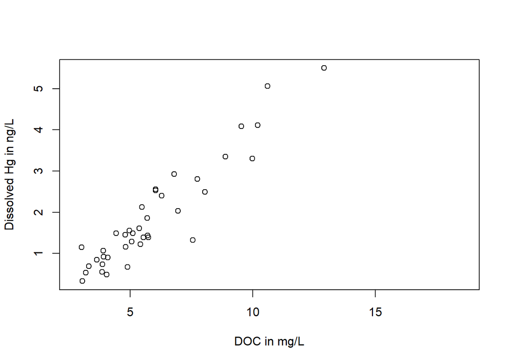

```r
#Visualize data in base plot
plot(wide$DOC, wide$Hg, xlab = "DOC in mg/L", ylab = "Dissolved Hg in ng/L")
```

# create a linear regression model and visualize residuals

```r
reg1 <- lm(data=wide, Hg ~ DOC) #create linear regression model
reg1 #this is the output of the linear model object
```

```
##
## Call:
## lm(formula = Hg ~ DOC, data = wide)
##
## Coefficients:
## (Intercept)          DOC
##      -1.108        0.504
```

```r
summary(reg1)
```

```
##
## Call:
## lm(formula = Hg ~ DOC, data = wide)
##
## Residuals:
##      Min       1Q   Median       3Q      Max
## -1.36734 -0.28592  0.02744  0.19012  0.82549
##
## Coefficients:
##             Estimate Std. Error t value Pr(>|t|)
## (Intercept) -1.10780    0.19163  -5.781 1.24e-06 ***
## DOC          0.50399    0.03022  16.678  < 2e-16 ***
## ---
## Signif. codes:  0 '***' 0.001 '**' 0.01 '*' 0.05 '.' 0.1 ' ' 1
##
## Residual standard error: 0.4364 on 37 degrees of freedom
##   (319 observations deleted due to missingness)
## Multiple R-squared:  0.8826, Adjusted R-squared:  0.8794
## F-statistic: 278.2 on 1 and 37 DF,  p-value: < 2.2e-16
```

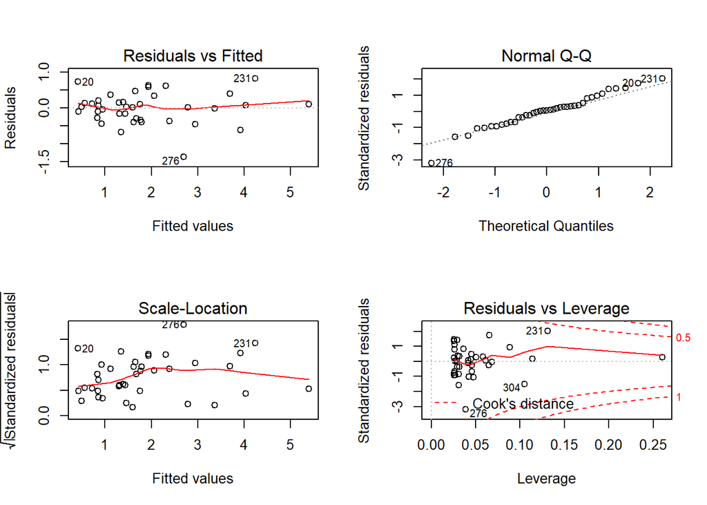

```r
par(mfrow=c(2,2))
plot(reg1)
```

```r
par(mfrow=c(1,1))
```

We wanted to see if DOC concentrations predict Hg concentrations (Formula = Hg ~ DOC) Residuals are mostly, but not completely symmetrical – might have a left skew, but that because we have 6 treatment groups in the data set

Estimate of intercept has a significant p-value, saying that it is significantly different from zero, but in real life, there are no negative Hg concentrations, so it is not valuable information

The estimate of “DOC” is actually the slope of the line, meaning that for each unit of DOC in mg/L, the concentration of Hg is expected to increase about a half of 1 ng/L. The *** and p-value < 0.05 indicate that the slope is significantly different from zero.

The R-squared values are a measure of “fit.” If all the data points fell on the regression line, R-squared = 1.

# plot the model on the data

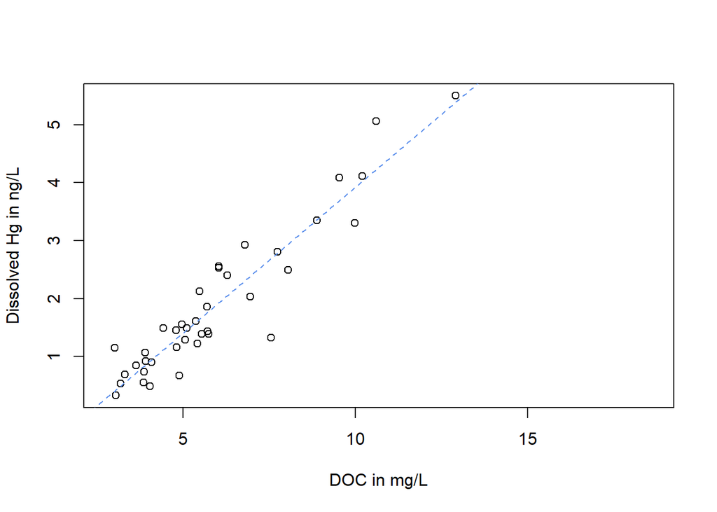

```r
plot(wide$DOC, wide$Hg, xlab = "DOC in mg/L", ylab = "Dissolved Hg in ng/L")
abline(reg1, lty = 2, col = "cornflowerblue")
```

# Pairwise comparisons

With different treatment groups, a common test is a t-test or a Tukey test. Let’s set up a couple of these tests with our data looking at the distribution (can we use parametric tests) and some groupings.

First we need to set up the class(Factors)

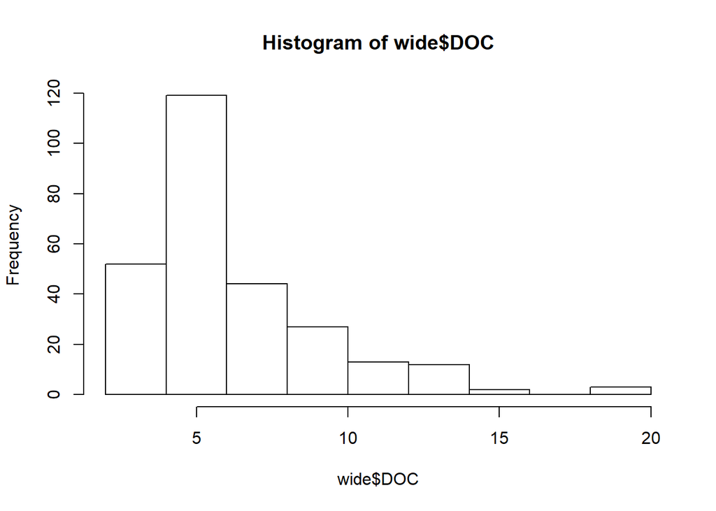

```r
wide$Site <- as.factor(wide$Site)
wide$Treatment <- as.factor(wide$Treatment)

#check for normality
hist(wide$DOC)
```

```r
shapiro.test(wide$DOC) # null hypothesis: data is normal
```

```
##
##  Shapiro-Wilk normality test
##
## data:  wide$DOC
## W = 0.83663, p-value = 2.97e-16
```

```r
shapiro.test(wide$Hg)
```

```
##
##  Shapiro-Wilk normality test
##
## data:  wide$Hg
## W = 0.88051, p-value = 0.0006382
```

```r
shapiro.test(wide$DOC[wide$Site == "Reference"])
```

```
##
##  Shapiro-Wilk normality test
##
## data:  wide$DOC[wide$Site == "Reference"]
## W = 0.92416, p-value = 1.364e-06
```

neither dataset is normally distributed (pvalue is less than 0.05), but for the interest of this excercise, lets look at both some parametric and non-parametric tests.

```r
#non-parametic example
kruskal.test(data = wide, DOC ~ Site) #like an anova, testing for differences in DOC concentration by Site
```

```
##
##  Kruskal-Wallis rank sum test
##
## data:  DOC by Site
## Kruskal-Wallis chi-squared = 87.655, df = 1, p-value < 2.2e-16
```

```r
kruskal.test(data = wide, DOC ~ Treatment) #testing for differences in DOC conc by Treatment
```

```
##
##  Kruskal-Wallis rank sum test
##
## data:  DOC by Treatment
## Kruskal-Wallis chi-squared = 32.728, df = 2, p-value = 7.82e-08
```

```r
# parametic example
aov1 <- aov(data = wide, DOC ~ Site + Treatment + Site*Treatment)
summary(aov1)
```

```
##                 Df Sum Sq Mean Sq F value   Pr(>F)
## Site             1  614.2   614.2  129.35  < 2e-16 ***
## Treatment        2  267.3   133.6   28.15 8.16e-12 ***
## Site:Treatment   2  149.9    74.9   15.78 3.34e-07 ***
## Residuals      266 1263.1     4.7
## ---
## Signif. codes:  0 '***' 0.001 '**' 0.01 '*' 0.05 '.' 0.1 ' ' 1
## 86 observations deleted due to missingness
```

```r
TukeyHSD(aov1)
```

```
##   Tukey multiple comparisons of means
##     95% family-wise confidence level
##
## Fit: aov(formula = DOC ~ Site + Treatment + Site * Treatment, data = wide)
##
## $Site
##                       diff      lwr      upr p adj
## Treated-Reference 3.005675 2.485327 3.526022     0
##
## $Treatment
##          diff        lwr        upr     p adj
## 2-1  2.966306  1.9576385  3.9749740 0.0000000
## 3-1  1.519890  0.8443845  2.1953964 0.0000007
## 3-2 -1.446416 -2.4191298 -0.4737017 0.0015506
##
## $`Site:Treatment`
##                               diff        lwr        upr     p adj
## Treated:1-Reference:1    1.0371739 -0.2179062  2.2922540 0.1698571
## Reference:2-Reference:1  0.9735294 -0.7660934  2.7131522 0.5950139
## Treated:2-Reference:1    6.0933333  4.3908598  7.7958069 0.0000000
## Reference:3-Reference:1  0.2514286 -0.9086116  1.4114687 0.9893315
## Treated:3-Reference:1    3.9290541  2.8095144  5.0485937 0.0000000
## Reference:2-Treated:1   -0.0636445 -1.8391178  1.7118288 0.9999984
## Treated:2-Treated:1      5.0561594  3.3170694  6.7952495 0.0000000
## Reference:3-Treated:1   -0.7857453 -1.9988864  0.4273957 0.4297172
## Treated:3-Treated:1      2.8918801  1.7174070  4.0663533 0.0000000
## Treated:2-Reference:2    5.1198039  3.0042672  7.2353406 0.0000000
## Reference:3-Reference:2 -0.7221008 -2.4317126  0.9875110 0.8305423
## Treated:3-Reference:2    2.9555246  1.2731310  4.6379183 0.0000125
## Reference:3-Treated:2   -5.8419048 -7.5137006 -4.1701090 0.0000000
## Treated:3-Treated:2     -2.1642793 -3.8082310 -0.5203276 0.0026479
## Treated:3-Reference:3    3.6776255  2.6053129  4.7499381 0.0000000
```

```r
anova(aov1)
```

```
## Analysis of Variance Table
##
## Response: DOC
##                 Df  Sum Sq Mean Sq F value    Pr(>F)
## Site             1  614.18  614.18 129.346 < 2.2e-16 ***
## Treatment        2  267.30  133.65  28.146 8.165e-12 ***
## Site:Treatment   2  149.85   74.93  15.780 3.342e-07 ***
## Residuals      266 1263.07    4.75
## ---
## Signif. codes:  0 '***' 0.001 '**' 0.01 '*' 0.05 '.' 0.1 ' ' 1
```

```r
library(multcomp)
wide$TMT <- interaction(wide$Site, wide$Treatment)
aovdoc <- aov(data = wide, DOC ~ Site + Treatment + Site*Treatment)
aov2 <- aov(data=wide, DOC ~ TMT)
summary(aovdoc)
```

```
##                 Df Sum Sq Mean Sq F value   Pr(>F)
## Site             1  614.2   614.2  129.35  < 2e-16 ***
## Treatment        2  267.3   133.6   28.15 8.16e-12 ***
## Site:Treatment   2  149.9    74.9   15.78 3.34e-07 ***
## Residuals      266 1263.1     4.7
## ---
## Signif. codes:  0 '***' 0.001 '**' 0.01 '*' 0.05 '.' 0.1 ' ' 1
## 86 observations deleted due to missingness
```

```r
summary(aov2)
```

```
##              Df Sum Sq Mean Sq F value Pr(>F)
## TMT           5   1031  206.27   43.44 <2e-16 ***
## Residuals   266   1263    4.75
## ---
## Signif. codes:  0 '***' 0.001 '**' 0.01 '*' 0.05 '.' 0.1 ' ' 1
## 86 observations deleted due to missingness
```

```r
cntrMat <- rbind(
  "Main effect of Site"=c(1, 1, 1, -1, -1, -1),
  "Main effect of treatment" = c(1, 1, -1, -1, -1, -1),
  "(ref1-treat1)-(ref3-treat3)"=c(1, 0, -1, -1, 0, 1),
  "(ref1-treat1)-(ref2-treat2)"=c(1,  -1, 0, -1, 1, 0),
  "(ref2-treat2)-(ref3-treat3)"=c(0, 1, -1, 0, -1, 1)
  )

# The contrasts above could also be labeled as differences between time periods (eg. (ref1-ref3)-(treat1-treat3)).  Mathematically, these are the same.

#general linear hypothesis
glht(aov2, linfct=mcp(TMT=cntrMat), alternative="two.sided") # alternative='two.sided' is the default
```

```
##
##   General Linear Hypotheses
##
## Multiple Comparisons of Means: User-defined Contrasts
##
##
## Linear Hypotheses:
##                                  Estimate
## Main effect of Site == 0           -8.263
## Main effect of treatment == 0     -10.210
## (ref1-treat1)-(ref3-treat3) == 0   -3.138
## (ref1-treat1)-(ref2-treat2) == 0   -6.879
## (ref2-treat2)-(ref3-treat3) == 0    3.741
```

```r
summary(glht(aov2, linfct=mcp(TMT=cntrMat)), test=adjusted("none"))
```

```
##
##   Simultaneous Tests for General Linear Hypotheses
##
## Multiple Comparisons of Means: User-defined Contrasts
##
##
## Fit: aov(formula = DOC ~ TMT, data = wide)
##
## Linear Hypotheses:
##                                  Estimate Std. Error t value Pr(>|t|)
## Main effect of Site == 0          -8.2631     0.9348  -8.840  < 2e-16 ***
## Main effect of treatment == 0    -10.2102     1.2559  -8.130 1.64e-14 ***
## (ref1-treat1)-(ref3-treat3) == 0  -3.1378     0.8338  -3.763 0.000206 ***
## (ref1-treat1)-(ref2-treat2) == 0  -6.8791     0.7282  -9.446  < 2e-16 ***
## (ref2-treat2)-(ref3-treat3) == 0   3.7413     0.7226   5.178 4.43e-07 ***
## ---
## Signif. codes:  0 '***' 0.001 '**' 0.01 '*' 0.05 '.' 0.1 ' ' 1
## (Adjusted p values reported -- none method)
```

The mcp() function {Multiple ComParisons} changes the hypothesis so that you are testing if the difference between the groups is zero.

Or, you can create an Rmarkdown and generate an easy to read table like this one:

```r
library(kableExtra)
library(broom)
kable(tidy(summary(glht(aov2, linfct=mcp(TMT=cntrMat), alternative="two.sided"), test=adjusted("none"))), digits = 3) %>% kable_styling(bootstrap_options = c("striped", "hover", 'responsive'), full_width = F)
```

| lhs | rhs | estimate | std.error | statistic | p.value |
| --- | --- | --- | --- | --- | --- |
| Main effect of Site | 0 | -8.263 | 0.935 | -8.840 | 0 |
| Main effect of treatment | 0 | -10.210 | 1.256 | -8.130 | 0 |
| (ref1-treat1)-(ref3-treat3) | 0 | -3.138 | 0.834 | -3.763 | 0 |
| (ref1-treat1)-(ref2-treat2) | 0 | -6.879 | 0.728 | -9.446 | 0 |
| (ref2-treat2)-(ref3-treat3) | 0 | 3.741 | 0.723 | 5.178 | 0 |